# 01_QualityTrimming

2025-03-01

```r
# Any number can be chosen
set.seed(238428)
```

# Timing of Script

```r
# What time did we start running this script?
start_time <- Sys.time()
start_time
```

```
## [1] "2025-03-10 18:07:26 EDT"
```

# Load Libraries

```r
# Efficient package loading with pacman
# Don't forget to install pacman and DT if you don't have it yet.
pacman::p_load(tidyverse, BiocManager, devtools, dada2,
               phyloseq, patchwork, DT, devtools, iNEXT, vegan, install = FALSE)
```

# Reading Raw Sequencing Files

```r
# Set the raw fastq path to the raw sequencing files
# Path to the fastq files
raw_fastqs_path <- "/local/workdir/lz592/MyProject/data/01_ena_data"
raw_fastqs_path
```

```
## [1] "/local/workdir/lz592/MyProject/data/01_ena_data"
```

```r
# What files are in this path? Intuition Check
head(list.files(raw_fastqs_path))
```

```
## [1] "SRR12873300_1.fastq.gz" "SRR12873300_2.fastq.gz" "SRR12873301_1.fastq.gz"
## [4] "SRR12873301_2.fastq.gz" "SRR12873302_1.fastq.gz" "SRR12873302_2.fastq.gz"
```

```r
# How many files are there?
length(list.files(raw_fastqs_path))
```

```
## [1] 58
```

```r
# Create vector of forward reads
forward_reads <- list.files(raw_fastqs_path, pattern = "_1.fastq.gz", full.names = TRUE)
# Intuition Checks
head(forward_reads)
```

```
## [1] "/local/workdir/lz592/MyProject/data/01_ena_data/SRR12873300_1.fastq.gz"
## [2] "/local/workdir/lz592/MyProject/data/01_ena_data/SRR12873301_1.fastq.gz"
## [3] "/local/workdir/lz592/MyProject/data/01_ena_data/SRR12873302_1.fastq.gz"
## [4] "/local/workdir/lz592/MyProject/data/01_ena_data/SRR12873303_1.fastq.gz"
## [5] "/local/workdir/lz592/MyProject/data/01_ena_data/SRR12873304_1.fastq.gz"
## [6] "/local/workdir/lz592/MyProject/data/01_ena_data/SRR12873305_1.fastq.gz"
```

```r
# Intuition check #2: We should have fewer reads in the forward vector than in total
stopifnot(length(forward_reads) < length(list.files(raw_fastqs_path)))

# Create a vector of reverse reads
reverse_reads <- list.files(raw_fastqs_path, pattern = "_2.fastq.gz", full.names = TRUE)
# Intuition Checks
head(reverse_reads)
```

```
## [1] "/local/workdir/lz592/MyProject/data/01_ena_data/SRR12873300_2.fastq.gz"
## [2] "/local/workdir/lz592/MyProject/data/01_ena_data/SRR12873301_2.fastq.gz"
## [3] "/local/workdir/lz592/MyProject/data/01_ena_data/SRR12873302_2.fastq.gz"
## [4] "/local/workdir/lz592/MyProject/data/01_ena_data/SRR12873303_2.fastq.gz"
## [5] "/local/workdir/lz592/MyProject/data/01_ena_data/SRR12873304_2.fastq.gz"
## [6] "/local/workdir/lz592/MyProject/data/01_ena_data/SRR12873305_2.fastq.gz"
```

```r
# Intuition check #2: Need to have equal number of forward and reverse files
stopifnot(length(reverse_reads) == length(forward_reads))
```

# Evaluate raw sequence quality

Seeing the quality of the raw reads *before* trimming # Plot 12 random samples of plots

```r
# Randomly select 12 samples from dataset to evaluate
# Selecting 12 is typically better than 2 (like we did in class for efficiency)
random_samples <- sample(1:length(reverse_reads), size = 12)
random_samples
```

```
##  [1] 27  8 13 17 16  7 19 28  4 22 11 20
```

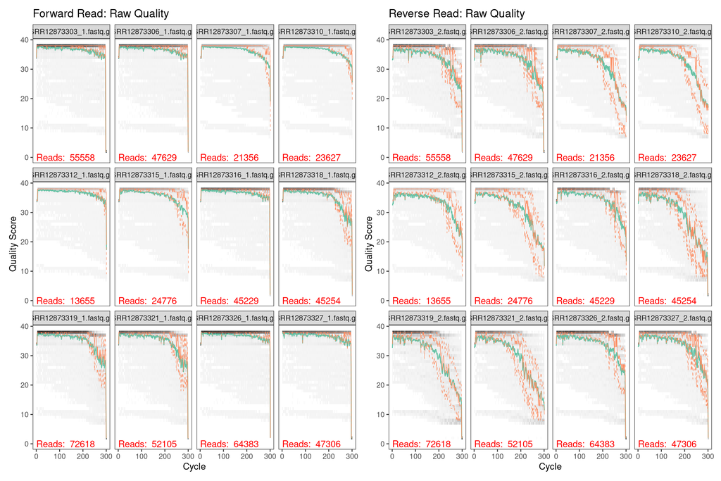

```r
# Calculate and plot quality of these twelve samples
forward_filteredQual_plot_12 <- plotQualityProfile(forward_reads[random_samples]) +
  labs(title = "Forward Read: Raw Quality")
reverse_filteredQual_plot_12 <- plotQualityProfile(reverse_reads[random_samples]) +
  labs(title = "Reverse Read: Raw Quality")

# Plot them together with patchwork
forward_filteredQual_plot_12 + reverse_filteredQual_plot_12
```

# Aggregated Raw Quality Plots

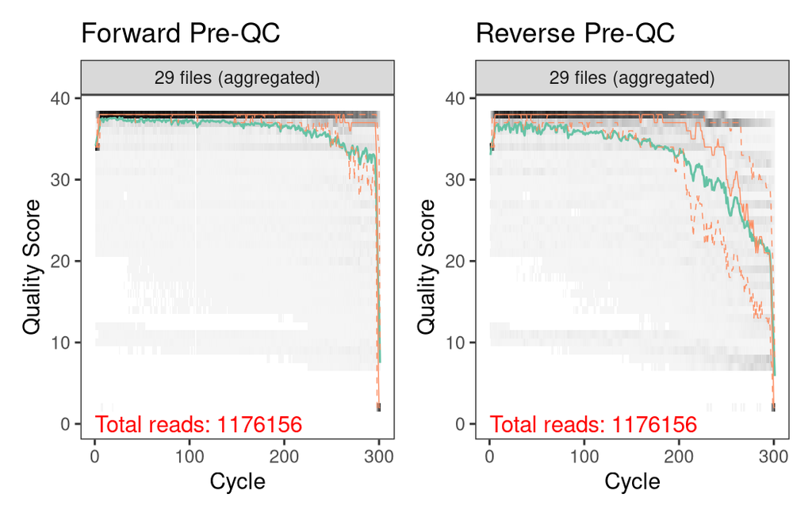

```r
# Aggregate all QC plots
# Forward reads
forward_preQC_plot <-
  plotQualityProfile(forward_reads, aggregate = TRUE) +
  labs(title = "Forward Pre-QC")

# reverse reads
reverse_preQC_plot <-
  plotQualityProfile(reverse_reads, aggregate = TRUE) +
  labs(title = "Reverse Pre-QC")

# Now, let's put the two plots together
preQC_aggregate_plot <-
  # Plot the forward and reverse together
  forward_preQC_plot + reverse_preQC_plot
# Show the plot
preQC_aggregate_plot
```

**INTERPRETATION #1 of Pre-QC:** *Here, in this location of your analyses, please insert a description of the interpretation you draw regarding your plots. You must note anything important about the figure you’ve created about your data including any spikes in quality and also the general trend of the raw QC plots.*

# Prepare a placeholder for filtered reads

```r
# Create vector of sample names from the filenames
sample_names <- sapply(strsplit(basename(forward_reads), "_"), `[`,1)

# Intuition Check
head(sample_names)
```

```
## [1] "SRR12873300" "SRR12873301" "SRR12873302" "SRR12873303" "SRR12873304"
## [6] "SRR12873305"
```

```r
# Place filtered reads into filtered_fastqs_path
filtered_fastqs_path <- "/local/workdir/lz592/MyProject/data//02_filtered_fastqs"

# Intuition Check
filtered_fastqs_path
```

```
## [1] "/local/workdir/lz592/MyProject/data//02_filtered_fastqs"
```

```r
# create 2 vectors: filtered_forward_reads & filtered_reverse_reads
filtered_forward_reads <-
  file.path(filtered_fastqs_path, paste0(sample_names, "1_filtered.fastq.gz"))

# Intuition Check
length(filtered_forward_reads)
```

```
## [1] 29
```

```r
# reverse reads
filtered_reverse_reads <-
  file.path(filtered_fastqs_path, paste0(sample_names, "2_filtered.fastq.gz"))

# Intuition Check
head(filtered_reverse_reads)
```

```
## [1] "/local/workdir/lz592/MyProject/data//02_filtered_fastqs/SRR128733002_filtered.fastq.gz"
## [2] "/local/workdir/lz592/MyProject/data//02_filtered_fastqs/SRR128733012_filtered.fastq.gz"
## [3] "/local/workdir/lz592/MyProject/data//02_filtered_fastqs/SRR128733022_filtered.fastq.gz"
## [4] "/local/workdir/lz592/MyProject/data//02_filtered_fastqs/SRR128733032_filtered.fastq.gz"
## [5] "/local/workdir/lz592/MyProject/data//02_filtered_fastqs/SRR128733042_filtered.fastq.gz"
## [6] "/local/workdir/lz592/MyProject/data//02_filtered_fastqs/SRR128733052_filtered.fastq.gz"
```

# Filter and Trim Reads

```r
# Assign and write out filtered fastq files
# Therefore, we do not need to trim the primers, because they were not sequenced
filtered_reads <-
  filterAndTrim(fwd = forward_reads, filt = filtered_forward_reads,
              rev = reverse_reads, filt.rev = filtered_reverse_reads,
              maxN = 0,
              # The sequence quality is not bad, so I choose to use maxEE = c(2,2)
              maxEE = c(2,2),
              # Trim the primers sequences in the forward and reverse reads
              trimLeft = c(16, 20),
              # Trim final 20 bases in the forward & trim final 90 bases in the reverse read
              truncLen = c(280, 210),
              truncQ = 2, rm.phix = TRUE, compress = TRUE, multithread = TRUE)
```

# Assess Trimmed Read Quality

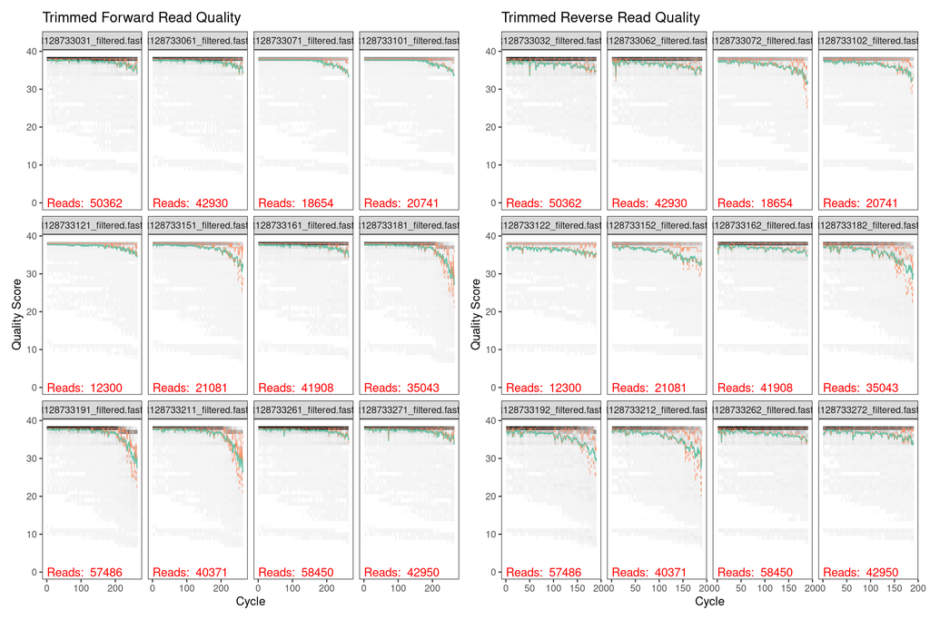

```r
# Plot the 12 random samples after QC
forward_filteredQual_plot_12 <-
  plotQualityProfile(filtered_forward_reads[random_samples]) +
  labs(title = "Trimmed Forward Read Quality")

reverse_filteredQual_plot_12 <-
  plotQualityProfile(filtered_reverse_reads[random_samples]) +
  labs(title = "Trimmed Reverse Read Quality")

# Put the two plots together
forward_filteredQual_plot_12 + reverse_filteredQual_plot_12
```

# Aggregated Trimmed Plots

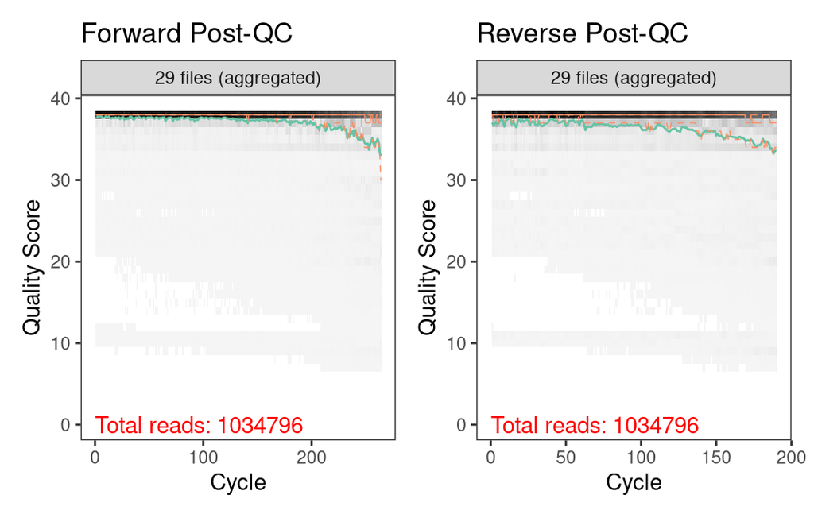

```r
# Aggregate all QC plots
# Forward reads
forward_postQC_plot <-
  plotQualityProfile(filtered_forward_reads, aggregate = TRUE) +
  labs(title = "Forward Post-QC")

# reverse reads
reverse_postQC_plot <-
  plotQualityProfile(filtered_reverse_reads, aggregate = TRUE) +
  labs(title = "Reverse Post-QC")

# Now, let's put the two plots together
postQC_aggregate_plot <-
  # Plot the forward and reverse together
  forward_postQC_plot + reverse_postQC_plot
# Show the plot
postQC_aggregate_plot
```

**INTERPRETATION #2 of Post-QC:** *Here, in this location of your analyses, please insert a description of the interpretation you draw regarding your post filterAndTrim plots. Please note anything important about the figure you’ve created about your data generally speaking to your post-QC reads. What’s the general trend? In the next question, we will plot the pre- and post-QC togeter and compare them. The goal here is to evaluate the QC process.*

The plots above show the post-QC quality scores of the sequencing data after applying quality filtering and trimming. Quality filtering successfully removed poor-quality reads and trimmed low-quality tails, leading to improved overall read quality. 1. Forward Reads Post-QC The forward reads maintain high quality (Q30+) throughout most of the read length. A slight decline in quality is visible after ~230 cycles, but still largely above a Phred of 30. 2. Reverse Reads Post-QC Initial bases (~0-10 cycles) remain stable, suggesting that any low-quality bases were effectively trimmed. The mid-read section (~10-170 cycles) maintains strong Q30+ quality with minimal degradation. A quality drop-off is still visible after ~170 cycles, but it is much less severe than before, meaning the QC process effectively removed the worst low-quality regions while preserving usable data.

# Read Retention Post-QC

```r
# Make output into dataframe
filtered_df <- as.data.frame(filtered_reads) %>%
  mutate(percent.retained = reads.out/reads.in)

# Intuition check
# Visualize it in table format
DT::datatable(filtered_df)
```

|  | reads.in | reads.out | percent.retained |
| --- | --- | --- | --- |
| SRR12873300_1.fastq.gz | 63484 | 58565 | 0.9225159095205091 |
| SRR12873301_1.fastq.gz | 45573 | 41736 | 0.9158054110986769 |
| SRR12873302_1.fastq.gz | 41649 | 37616 | 0.9031669427837403 |
| SRR12873303_1.fastq.gz | 55558 | 50362 | 0.9064761150509377 |
| SRR12873304_1.fastq.gz | 51667 | 46870 | 0.9071554377068535 |
| SRR12873305_1.fastq.gz | 46215 | 42415 | 0.9177756139781457 |
| SRR12873306_1.fastq.gz | 47629 | 42930 | 0.9013416196015033 |
| SRR12873307_1.fastq.gz | 21356 | 18654 | 0.873478179434351 |
| SRR12873308_1.fastq.gz | 19812 | 17344 | 0.8754290329093478 |
| SRR12873309_1.fastq.gz | 23730 | 21020 | 0.8857985672144965 |

[output cut: 19 more lines]

```r
# Let's calculate some statistics
read_stats_df <-
  filtered_df %>%
  reframe(median_reads_in = median(reads.in),
          median_reads_out = median(reads.out),
          median_percent_retained = (median(reads.out)/median(reads.in)),
          max_percent_retained = max(reads.out/reads.in),
          min_percent_retained = min(reads.out/reads.in))

# Take a look at it!
read_stats_df
```

```
##   median_reads_in median_reads_out median_percent_retained max_percent_retained
## 1           45573            41736               0.9158054            0.9265737
##   min_percent_retained
## 1            0.7743625
```

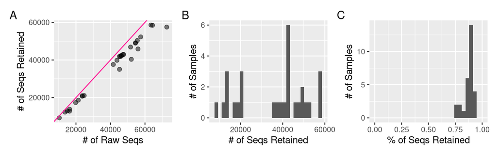

```r
# Plot it
numSeqs_QC_dotplot <-
  filtered_df %>%
  ggplot(aes(x = reads.in, y = reads.out)) +
  geom_point(alpha = 0.5, size = 2) +
  labs(x = "# of Raw Seqs",
       y = "# of Seqs Retained") +
  # Now let's add a 1:1 line for reference of keeping 100% of the reads
  geom_abline(slope=1, intercept = 0, color = "deeppink")

# Now, let's look at the number of reads retained in a histogram
numRetained_QC_histplot <-
  filtered_df %>%
  ggplot(aes(x = reads.out)) +
  geom_histogram() +
  labs(x = "# of Seqs Retained",
       y = "# of Samples")

# Create a histogram of percent reads retained in a histogram
percSeqs_QC_histplot <-
  filtered_df %>%
  ggplot(aes(x = percent.retained)) +
  geom_histogram() +
  labs(x = "% of Seqs Retained",
       y = "# of Samples") +
  # Set the scale to be between 0-1 (0-100%)
  scale_x_continuous(limits = c(0, 1))

# Now, let's put the plots together
numSeqs_QC_dotplot + numRetained_QC_histplot + percSeqs_QC_histplot +
  plot_annotation(tag_levels = 'A')
```

**INTERPRETATION #3 of Post-QC Statistics:** *Here, in this location of your analyses, please insert a description of the interpretation you draw regarding your read retainment pre- and post-QC. Please note anything important about the three paneled figure you created above. Think about how many reads got through? Is it “enough”? Should I play with the parameters in filterAndTrim() more? If so, which parameters?*

This figure presents three panels showing how many sequences were retained after quality filtering and trimming in the DADA2 pipeline.

Panel A: Scatter Plot of Raw vs. Retained Sequences • X-axis: Number of raw sequences before filtering. • Y-axis: Number of sequences retained after filtering. • Pink Line: The diagonal line represents perfect retention (i.e., no sequences lost). Interpretation of Panel A: Most points are close to the diagonal, suggesting good read retention across samples. Some points fall below the diagonal, indicating that a few samples lost a moderate number of reads. No extreme outliers, meaning no sample was unexpectedly depleted. Overall: The filtering step was effective while preserving most sequences, ensuring sufficient data retention.

# Visualize QC differences in plot

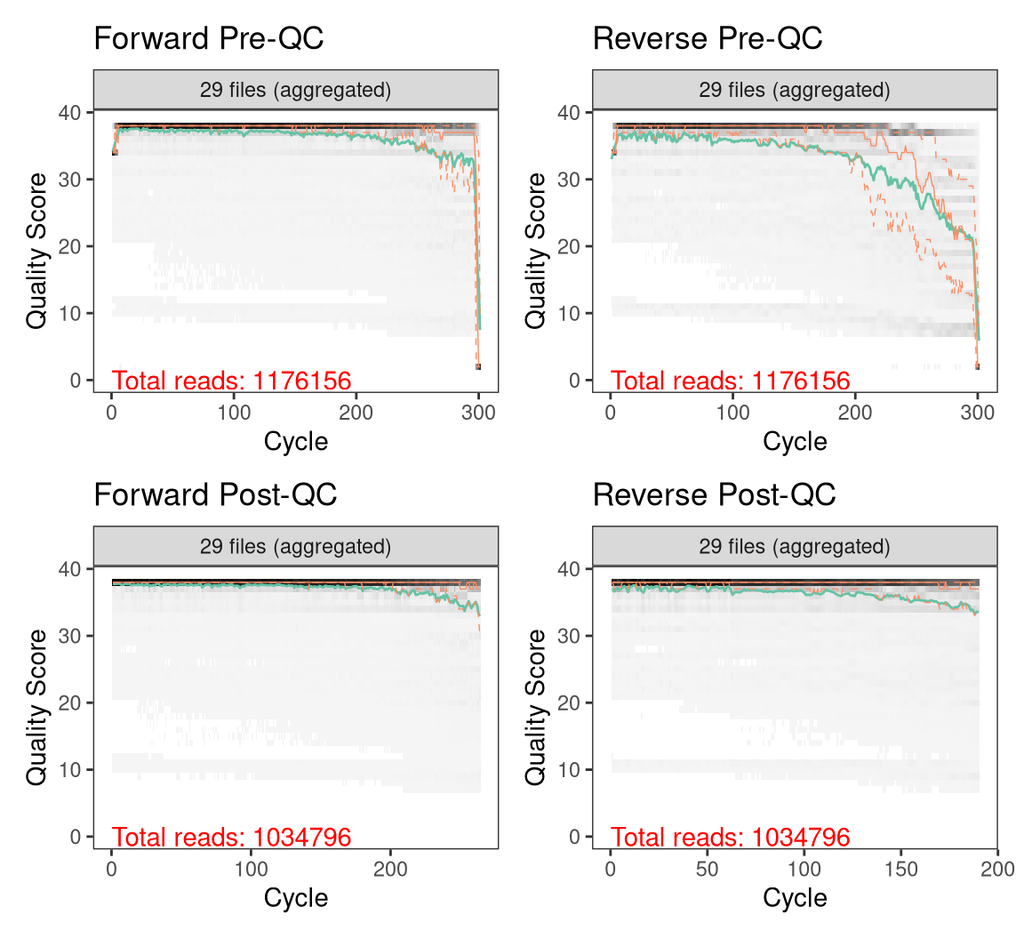

```r
# Plot the pre and post together in one plot
preQC_aggregate_plot / postQC_aggregate_plot
```

**INTERPRETATION #4 is comparing your pre-QC to your post-QC read quality:** *Here, in this location of your analyses, please insert a description of the interpretation you draw from yor overall quality control results. Are you satisfied with your QC process?*

Quality Score Improvements 1. Forward Reads (Pre vs. Post-QC) • Beginning of read: The primers were trimmed at the beginning of forward and reverse reads. • Middle of read: The quality remains consistently high Q30-Q40 across most cycles/bases. • End of read: While a slight drop in the last ~20 cycles/bases remain, the trimming step remove the lowest-quality bases. 2. Reverse Reads (Pre vs. Post-QC) • Beginning of read: The primers were trimmed at the beginning of forward and reverse reads. • Middle of read: Mid-read quality (~10-180bp) remains strong. • End of read: The trailing end of the reverse reads still shows some degradation, but it’s significantly improved from pre-QC. The lowest-quality bases have been trimmed, but reverse reads still have some expected drop-off after ~180 cycles (this is typical for Illumina sequencing).

# Check Render Time

```r
# Take the time now that we are at the end of the script
end_time <- Sys.time()
end_time
```

```
## [1] "2025-03-10 18:13:00 EDT"
```

```r
# Echo the elapsed time
elapsed_time <- round((end_time - start_time), 3)
elapsed_time
```

```
## Time difference of 5.569 mins
```

I think I have sufficiently QC’d the sequencing data, and I trust the quality of the data.